[figure not shown]

# Artificial Intelligence and Machine Learning

## Model Deployment - Project

[figure not shown]

SuperKart : Forecast Sales Revenue

# **Problem Statement**

## Business Context

A sales forecast is a prediction of future sales revenue based on historical data, industry trends, and the status of the current sales pipeline. Businesses use the sales forecast to estimate weekly, monthly, quarterly, and annual sales totals. A company needs to make an accurate sales forecast as it adds value across an organization and helps the different verticals to chalk out their future course of action.

Forecasting helps an organization plan its sales operations by region and provides valuable insights to the supply chain team regarding the procurement of goods and materials. An accurate sales forecast process has many benefits which include improved decision-making about the future and reduction of sales pipeline and forecast risks. Moreover, it helps to reduce the time spent in planning territory coverage and establish benchmarks that can be used to assess trends in the future.

## Objective

SuperKart is a retail chain operating supermarkets and food marts across various tier cities, offering a wide range of products. To optimize its inventory management and make informed decisions around regional sales strategies, SuperKart wants to accurately forecast the sales revenue of its outlets for the upcoming quarter.

To operationalize these insights at scale, the company has partnered with a data science firm—not just to build a predictive model based on historical sales data, but to develop and deploy a robust forecasting solution that can be integrated into SuperKart’s decision-making systems and used across its network of stores.

## Data Description

The data contains the different attributes of the various products and stores.The detailed data dictionary is given below.

- **Product_Id** - unique identifier of each product, each identifier having two letters at the beginning followed by a number.
- **Product_Weight** - weight of each product
- **Product_Sugar_Content** - sugar content of each product like low sugar, regular and no sugar
- **Product_Allocated_Area** - ratio of the allocated display area of each product to the total display area of all the products in a store
- **Product_Type** - broad category for each product like meat, snack foods, hard drinks, dairy, canned, soft drinks, health and hygiene, baking goods, bread, breakfast, frozen foods, fruits and vegetables, household, seafood, starchy foods, others
- **Product_MRP** - maximum retail price of each product
- **Store_Id** - unique identifier of each store
- **Store_Establishment_Year** - year in which the store was established
- **Store_Size** - size of the store depending on sq. feet like high, medium and low
- **Store_Location_City_Type** - type of city in which the store is located like Tier 1, Tier 2 and Tier 3. Tier 1 consists of cities where the standard of living is comparatively higher than its Tier 2 and Tier 3 counterparts.
- **Store_Type** - type of store depending on the products that are being sold there like Departmental Store, Supermarket Type 1, Supermarket Type 2 and Food Mart
- **Product_Store_Sales_Total** - total revenue generated by the sale of that particular product in that particular store

# **Installing and Importing the necessary libraries**

## Installation

**Please Note:**

- The notebook is run using a local jupyter running on a conda environment
- No packages are installed via the notebook. They are used from the conda env (named 'genai')
- Local env is a Macbook M3 (Google colab not used). Used to manage session timeout challenge of google colab

```python
import os
print("Local machine Conda environment name : " +os.environ['CONDA_DEFAULT_ENV'])
```

```
Local machine Conda environment name : genai
```

```python
import tensorflow as tf
print("Num GPUs Available:", len(tf.config.list_physical_devices('GPU')))
print(tf.__version__)
print("Local Machine config : ")
print(tf.config.list_physical_devices()[0])
```

```
Num GPUs Available: 0
2.18.1
Local Machine config :
PhysicalDevice(name='/physical_device:CPU:0', device_type='CPU')
```

## Importing libraries

Following important libraries are loaded

1. Pandas & Numpy
2. Matplotlib, Seaborn
3. Scikit, XGBoost
4. APIRequests, Joblib, hugging face hub

```python
# Libraries to help with reading and manipulating data
import numpy as np
import pandas as pd

import sklearn
import xgboost

# Libaries to help with data visualization
import matplotlib.pyplot as plt
import seaborn as sns

# Removes the limit for the number of displayed columns
pd.set_option("display.max_columns", None)
# Sets the limit for the number of displayed rows
pd.set_option("display.max_rows", 100)

# For splitting the dataset, preprocessing
from sklearn.model_selection import train_test_split
from sklearn.impute import SimpleImputer
from sklearn.preprocessing import StandardScaler, OneHotEncoder
from sklearn.compose import make_column_transformer

# To create the pipeline
from sklearn.pipeline import make_pipeline
from sklearn.pipeline import Pipeline # Import Pipeline

# for model training, tuning, and evaluation (regression metrics)
from sklearn.ensemble import RandomForestRegressor
from xgboost import XGBRegressor
from sklearn.model_selection import GridSearchCV
from sklearn.metrics import (
    mean_squared_error,
    mean_absolute_error,
    r2_score,
    mean_absolute_percentage_error,
    root_mean_squared_error,
)

# To serialize the model
import joblib

# os related functionalities
import os

# API request
import requests

# for hugging face space authentication to upload files
from huggingface_hub import login, HfApi

# import and filter warnings
import warnings
warnings.filterwarnings("ignore")

from datetime import datetime  # added for dynamic current year
# dynamically obtain the current calendar year
```

```python
# Set scikit-learn's display mode to 'diagram' for better visualization of pipelines and estimators
sklearn.set_config(display='diagram')
```

# **Loading the dataset**

```python
# Load the dataset from a CSV file into a Pandas DataFrame
superkart_data = pd.read_csv("SuperKart.csv",low_memory=False)
```

```python
# Create a copy of the dataframe
dataset = superkart_data.copy()
```

# **Data Overview**

## Shape of the data

```python
# print the dataset shape
dataset.shape
```

```
(8763, 12)
```

- There are 8763 rows and 12 columns

## Data types of various attributes

### Column names

```python
# Display the column names of the dataset
dataset.columns
```

```
Index(['Product_Id', 'Product_Weight', 'Product_Sugar_Content',
       'Product_Allocated_Area', 'Product_Type', 'Product_MRP', 'Store_Id',
       'Store_Establishment_Year', 'Store_Size', 'Store_Location_City_Type',
       'Store_Type', 'Product_Store_Sales_Total'],
      dtype='object')
```

- The 12 columns are matching as per the data dictionary provided in the problem statement

### Data types

```python
# checking column datatypes and number of non-null values
dataset.info()
```

```
<class 'pandas.core.frame.DataFrame'>
RangeIndex: 8763 entries, 0 to 8762
Data columns (total 12 columns):
 #   Column                     Non-Null Count  Dtype
---  ------                     --------------  -----
 0   Product_Id                 8763 non-null   object
 1   Product_Weight             8763 non-null   float64
 2   Product_Sugar_Content      8763 non-null   object
 3   Product_Allocated_Area     8763 non-null   float64
 4   Product_Type               8763 non-null   object
 5   Product_MRP                8763 non-null   float64
 6   Store_Id                   8763 non-null   object
 7   Store_Establishment_Year   8763 non-null   int64
 8   Store_Size                 8763 non-null   object
 9   Store_Location_City_Type   8763 non-null   object
 10  Store_Type                 8763 non-null   object
 11  Product_Store_Sales_Total  8763 non-null   float64
dtypes: float64(4), int64(1), object(7)
memory usage: 821.7+ KB
```

- There are 7 object column types and 5 number column types (float64, int64)

### First '5' rows and identifier Column

```python
# Display the first five rows of the dataset
dataset.head()
```

|  | Product_Id | Product_Weight | Product_Sugar_Content | Product_Allocated_Area | Product_Type | Product_MRP | Store_Id | Store_Establishment_Year | Store_Size | Store_Location_City_Type | Store_Type | Product_Store_Sales_Total |
| --- | --- | --- | --- | --- | --- | --- | --- | --- | --- | --- | --- | --- |
| 0 | FD6114 | 12.66 | Low Sugar | 0.027 | Frozen Foods | 117.08 | OUT004 | 2009 | Medium | Tier 2 | Supermarket Type2 | 2842.40 |
| 1 | FD7839 | 16.54 | Low Sugar | 0.144 | Dairy | 171.43 | OUT003 | 1999 | Medium | Tier 1 | Departmental Store | 4830.02 |
| 2 | FD5075 | 14.28 | Regular | 0.031 | Canned | 162.08 | OUT001 | 1987 | High | Tier 2 | Supermarket Type1 | 4130.16 |
| 3 | FD8233 | 12.10 | Low Sugar | 0.112 | Baking Goods | 186.31 | OUT001 | 1987 | High | Tier 2 | Supermarket Type1 | 4132.18 |
| 4 | NC1180 | 9.57 | No Sugar | 0.010 | Health and Hygiene | 123.67 | OUT002 | 1998 | Small | Tier 3 | Food Mart | 2279.36 |

```python
# Print the unique count in the identifier column `Product_Id`
dataset['Product_Id'].unique
```

```
<bound method Series.unique of 0       FD6114
1       FD7839
2       FD5075
3       FD8233
4       NC1180
         ...
8758    NC7546
8759     NC584
8760    NC2471
8761    NC7187
8762     FD306
Name: Product_Id, Length: 8763, dtype: object>
```

### Observation of data types

- Identifier Column :
  1. `Product_Id`
- Categorical Columns
  1. `Product_Sugar_Content`
  2. `Product_Type`
  3. `Store_Id`
  4. `Store_Size`
  5. `Store_Location_City_Type`
  6. `Store_Type`
- Numeric Columns
  1. `Product_Weight`
  2. `Product_Allocated_Area`
  3. `Product_MRP`
  4. `Store_Establishment_Year` (Its a numeric data type, but while analysing should it be treated in buckets of years or not will be evaluated)
  5. `Product_Store_Sales_Total` (Target variable Y, for the given regression problem)

## Missing Values

```python
# checking for missing values
dataset.isnull().sum()
```

```
Product_Id                   0
Product_Weight               0
Product_Sugar_Content        0
Product_Allocated_Area       0
Product_Type                 0
Product_MRP                  0
Store_Id                     0
Store_Establishment_Year     0
Store_Size                   0
Store_Location_City_Type     0
Store_Type                   0
Product_Store_Sales_Total    0
dtype: int64
```

- The dataset does not have any missing values in any column.

## Duplicate values

```python
# checking for duplicate values
dataset.duplicated().sum()
```

```
np.int64(0)
```

- There are no duplicate values in the dataset

## Category columns validation

```python
# define the list of categorical column names in a single variable
category_columns =['Product_Sugar_Content','Product_Type','Store_Id','Store_Size','Store_Location_City_Type','Store_Type']
```

```python
# print the unique values in each category column
for category in category_columns:
  print(f"Unique values in `{category}` are ")
  print(dataset[category].value_counts())
  print('-'*50)
```

```
Unique values in `Product_Sugar_Content` are
Product_Sugar_Content
Low Sugar    4885
Regular      2251
No Sugar     1519
reg           108
Name: count, dtype: int64
--------------------------------------------------
Unique values in `Product_Type` are
Product_Type
Fruits and Vegetables    1249
Snack Foods              1149
Frozen Foods              811
Dairy                     796
Household                 740
Baking Goods              716
Canned                    677
Health and Hygiene        628
Meat                      618
Soft Drinks               519
Breads                    200
Hard Drinks               186
Others                    151
Starchy Foods             141
Breakfast                 106
Seafood                    76
Name: count, dtype: int64
--------------------------------------------------
Unique values in `Store_Id` are
Store_Id
OUT004    4676
OUT001    1586
OUT003    1349
OUT002    1152
Name: count, dtype: int64
--------------------------------------------------
Unique values in `Store_Size` are
Store_Size
Medium    6025
High      1586
Small     1152
Name: count, dtype: int64
--------------------------------------------------
Unique values in `Store_Location_City_Type` are
Store_Location_City_Type
Tier 2    6262
Tier 1    1349
Tier 3    1152
Name: count, dtype: int64
--------------------------------------------------
Unique values in `Store_Type` are
Store_Type
Supermarket Type2     4676
Supermarket Type1     1586
Departmental Store    1349
Food Mart             1152
Name: count, dtype: int64
--------------------------------------------------
```

**Observations**

- The column `Product_Sugar_Content` has 2 values "Regular" and "reg"
- We can check the records that have 'reg' as value

```python
# print records with 'reg' value for sugar content
dataset[dataset['Product_Sugar_Content']=='reg']
```

|  | Product_Id | Product_Weight | Product_Sugar_Content | Product_Allocated_Area | Product_Type | Product_MRP | Store_Id | Store_Establishment_Year | Store_Size | Store_Location_City_Type | Store_Type | Product_Store_Sales_Total |
| --- | --- | --- | --- | --- | --- | --- | --- | --- | --- | --- | --- | --- |
| 43 | DR2126 | 7.82 | reg | 0.036 | Hard Drinks | 102.18 | OUT002 | 1998 | Small | Tier 3 | Food Mart | 1443.06 |
| 87 | FD5746 | 11.59 | reg | 0.091 | Dairy | 145.79 | OUT004 | 2009 | Medium | Tier 2 | Supermarket Type2 | 3188.61 |
| 118 | FD3884 | 11.72 | reg | 0.102 | Baking Goods | 143.79 | OUT004 | 2009 | Medium | Tier 2 | Supermarket Type2 | 3175.51 |
| 134 | FD1368 | 16.29 | reg | 0.184 | Frozen Foods | 217.94 | OUT003 | 1999 | Medium | Tier 1 | Departmental Store | 5726.19 |
| 143 | FD8450 | 14.08 | reg | 0.074 | Breads | 127.51 | OUT004 | 2009 | Medium | Tier 2 | Supermarket Type2 | 3375.71 |
| ... | ... | ... | ... | ... | ... | ... | ... | ... | ... | ... | ... | ... |
| 8037 | FD4281 | 14.56 | reg | 0.105 | Baking Goods | 180.21 | OUT001 | 1987 | High | Tier 2 | Supermarket Type1 | 4562.36 |
| 8076 | FD5788 | 11.62 | reg | 0.054 | Canned | 136.42 | OUT004 | 2009 | Medium | Tier 2 | Supermarket Type2 | 3001.97 |
| 8185 | FD8547 | 11.80 | reg | 0.029 | Breads | 144.64 | OUT004 | 2009 | Medium | Tier 2 | Supermarket Type2 | 3212.19 |
| 8211 | FD8751 | 12.75 | reg | 0.056 | Fruits and Vegetables | 227.47 | OUT003 | 1999 | Medium | Tier 1 | Departmental Store | 5120.87 |
| 8477 | FD4568 | 14.39 | reg | 0.057 | Baking Goods | 184.41 | OUT001 | 1987 | High | Tier 2 | Supermarket Type1 | 4609.95 |

108 rows × 12 columns

- The records are across different product types and the value 'reg' appears to be a typo of 'Regular'. This can be modified to be 'Regular' from 'reg'

```python
# Replace 'reg' with 'Regular' in the Product_Sugar_Content column
dataset['Product_Sugar_Content'].replace('reg', 'Regular', inplace=True)
dataset['Product_Sugar_Content'].value_counts()
```

```
Product_Sugar_Content
Low Sugar    4885
Regular      2359
No Sugar     1519
Name: count, dtype: int64
```

## Feature Engineering : Store Age

- It is recommended to modify the establishment year to age w.r.t current year
- Keeping the absolute numeric value for establishment year may make the models misinterpret the numeric distance as linear
- Also Age will be more interpretable for business insights like older vs recent stores

```python
# print the unique years the stores were established
dataset['Store_Establishment_Year'].value_counts()
```

```
Store_Establishment_Year
2009    4676
1987    1586
1999    1349
1998    1152
Name: count, dtype: int64
```

**Observations:**

- There are only 4 years.
- The data type, instead of computing the age, could also be modified as object (category). But, by making it categorical avoids forcing the models to treat years as continuous, which may mislead splits.
- Also for business interpretability, store age is often more intuitive. So Age will be computed.

```python
# Compute Store Age from Store_Establishment_Year to current year
current_year = datetime.now().year
dataset['Store_Age'] = current_year - dataset['Store_Establishment_Year']
```

```python
# print top 5 values to check the `Store_Age`
dataset.head()
```

|  | Product_Id | Product_Weight | Product_Sugar_Content | Product_Allocated_Area | Product_Type | Product_MRP | Store_Id | Store_Establishment_Year | Store_Size | Store_Location_City_Type | Store_Type | Product_Store_Sales_Total | Store_Age |
| --- | --- | --- | --- | --- | --- | --- | --- | --- | --- | --- | --- | --- | --- |
| 0 | FD6114 | 12.66 | Low Sugar | 0.027 | Frozen Foods | 117.08 | OUT004 | 2009 | Medium | Tier 2 | Supermarket Type2 | 2842.40 | 16 |
| 1 | FD7839 | 16.54 | Low Sugar | 0.144 | Dairy | 171.43 | OUT003 | 1999 | Medium | Tier 1 | Departmental Store | 4830.02 | 26 |
| 2 | FD5075 | 14.28 | Regular | 0.031 | Canned | 162.08 | OUT001 | 1987 | High | Tier 2 | Supermarket Type1 | 4130.16 | 38 |
| 3 | FD8233 | 12.10 | Low Sugar | 0.112 | Baking Goods | 186.31 | OUT001 | 1987 | High | Tier 2 | Supermarket Type1 | 4132.18 | 38 |
| 4 | NC1180 | 9.57 | No Sugar | 0.010 | Health and Hygiene | 123.67 | OUT002 | 1998 | Small | Tier 3 | Food Mart | 2279.36 | 27 |

- Store_Age has been computed and added to the dataset

## Numerical column validation

- We will also check the numerical columns for negative values

```python
# List of numerical features in the dataset (excluding 'id' as it is an identifier)
# Note : 'Product_Store_Sales_Total' is not included as it is the target variable
numeric_features = [
    'Product_Weight',
    'Product_Allocated_Area',
    'Product_MRP',
    'Store_Age'
]

# Create a dictionary to store columns with negative values
negative_values = {}

# Loop through each numerical column to check for negatives
for col in numeric_features:
    # Filter rows where the column has negative values
    negatives = dataset[dataset[col] < 0][col]

    # If any negative values exist, store them in the dictionary
    if not negatives.empty:
        negative_values[col] = negatives

# Display the columns with negative values (if any)
negative_values
```

```
{}
```

- There are no numeric columns with negative values

## Statistical Summary

```python
# display the statistical summary of all columns
dataset.describe(include='all').T
```

|  | count | unique | top | freq | mean | std | min | 25% | 50% | 75% | max |
| --- | --- | --- | --- | --- | --- | --- | --- | --- | --- | --- | --- |
| Product_Id | 8763 | 8763 | FD6114 | 1 | NaN | NaN | NaN | NaN | NaN | NaN | NaN |
| Product_Weight | 8763.0 | NaN | NaN | NaN | 12.653792 | 2.21732 | 4.0 | 11.15 | 12.66 | 14.18 | 22.0 |
| Product_Sugar_Content | 8763 | 3 | Low Sugar | 4885 | NaN | NaN | NaN | NaN | NaN | NaN | NaN |
| Product_Allocated_Area | 8763.0 | NaN | NaN | NaN | 0.068786 | 0.048204 | 0.004 | 0.031 | 0.056 | 0.096 | 0.298 |
| Product_Type | 8763 | 16 | Fruits and Vegetables | 1249 | NaN | NaN | NaN | NaN | NaN | NaN | NaN |
| Product_MRP | 8763.0 | NaN | NaN | NaN | 147.032539 | 30.69411 | 31.0 | 126.16 | 146.74 | 167.585 | 266.0 |
| Store_Id | 8763 | 4 | OUT004 | 4676 | NaN | NaN | NaN | NaN | NaN | NaN | NaN |
| Store_Establishment_Year | 8763.0 | NaN | NaN | NaN | 2002.032751 | 8.388381 | 1987.0 | 1998.0 | 2009.0 | 2009.0 | 2009.0 |
| Store_Size | 8763 | 3 | Medium | 6025 | NaN | NaN | NaN | NaN | NaN | NaN | NaN |
| Store_Location_City_Type | 8763 | 3 | Tier 2 | 6262 | NaN | NaN | NaN | NaN | NaN | NaN | NaN |
| Store_Type | 8763 | 4 | Supermarket Type2 | 4676 | NaN | NaN | NaN | NaN | NaN | NaN | NaN |
| Product_Store_Sales_Total | 8763.0 | NaN | NaN | NaN | 3464.00364 | 1065.630494 | 33.0 | 2761.715 | 3452.34 | 4145.165 | 8000.0 |
| Store_Age | 8763.0 | NaN | NaN | NaN | 22.967249 | 8.388381 | 16.0 | 16.0 | 16.0 | 27.0 | 38.0 |

# **Exploratory Data Analysis (EDA)**

Following sections will perform the univariate and bivariate analysis

## Univariate Analysis

### Numerical variables and histogram

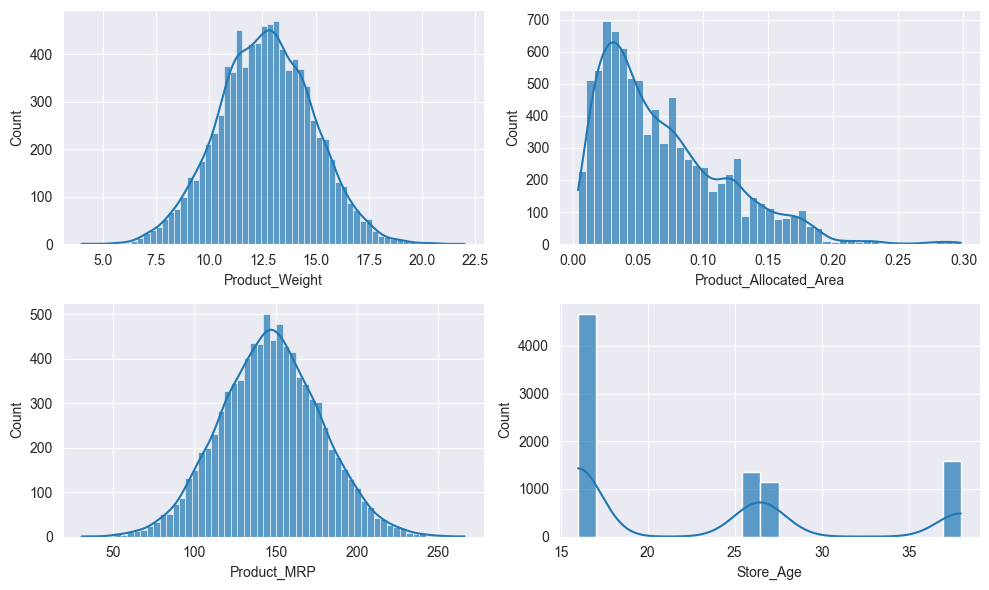

```python
# define the plot figure size
plt.figure(figsize=(10, 6))

# plotting the histogram for each numerical feature
for i, feature in enumerate(numeric_features):
    plt.subplot(2, 2, i+1)    # assign a subplot in the main plot
    sns.histplot(data=dataset, x=feature, kde=True, alpha=0.7)    # plot the histogram on log scale

plt.tight_layout();   # to add spacing between plots
plt.show()
```

**Analysis:**

`Product_Weight`

- Distribution is approximately normal (bell-shaped) centered around ~12, 13.
- Few outliers exist on the lower (~4–6) and higher (~20+) ends.

`Product_Allocated_Area`

- Right-skewed distribution with most values clustered below 0.1.
- A small number of products are allocated disproportionately larger display areas (>0.15).
- Indicates majority of products occupy small shelf space, while few dominate

`Product_MRP`

- Roughly normal distribution centered around ~140 to 150.
- Range spans broadly (30 to 260), but bulk of products priced in mid-range.

`Store_Age`

- Multi-modal distribution with peaks at ~16, ~27, and ~38 years from the store open. Understandable as earlier it was observed that only in 4 distinct years stores were opened.
- Heavy concentration at 16 years (Stores opened recently at 2009), with smaller clusters for older ones.

### Numerical variables and Box plots

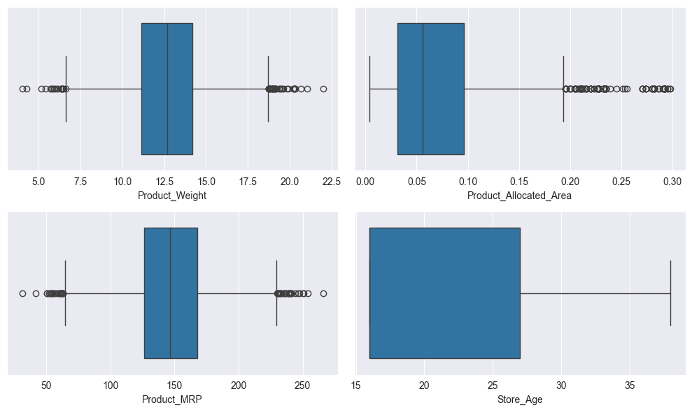

```python
# define the plot figure size
plt.figure(figsize=(10, 6))

# plotting the boxplots for each numerical feature
for i, feature in enumerate(numeric_features):
    plt.subplot(2, 2, i+1)    # assign a subplot in the main plot
    sns.boxplot(data=dataset, x=feature)    # plot the boxplot

plt.tight_layout();   # to add spacing between plots
plt.show()
```

**Analysis:**

Overall the observations from histplot and boxplot are complementing each other.

### Category variables and Count plots

- countplots will be drawn and analysed for categorical features

```python
# Print feature value counts in percentage
for feature in category_columns:
    counts = dataset[feature].value_counts()
    print(f"{feature}: ", end='')
    print(' | '.join([f"{idx}: {val}" for idx, val in counts.items()]))
```

```
Product_Sugar_Content: Low Sugar: 4885 | Regular: 2359 | No Sugar: 1519
Product_Type: Fruits and Vegetables: 1249 | Snack Foods: 1149 | Frozen Foods: 811 | Dairy: 796 | Household: 740 | Baking Goods: 716 | Canned: 677 | Health and Hygiene: 628 | Meat: 618 | Soft Drinks: 519 | Breads: 200 | Hard Drinks: 186 | Others: 151 | Starchy Foods: 141 | Breakfast: 106 | Seafood: 7…
Store_Id: OUT004: 4676 | OUT001: 1586 | OUT003: 1349 | OUT002: 1152
Store_Size: Medium: 6025 | High: 1586 | Small: 1152
Store_Location_City_Type: Tier 2: 6262 | Tier 1: 1349 | Tier 3: 1152
Store_Type: Supermarket Type2: 4676 | Supermarket Type1: 1586 | Departmental Store: 1349 | Food Mart: 1152
```

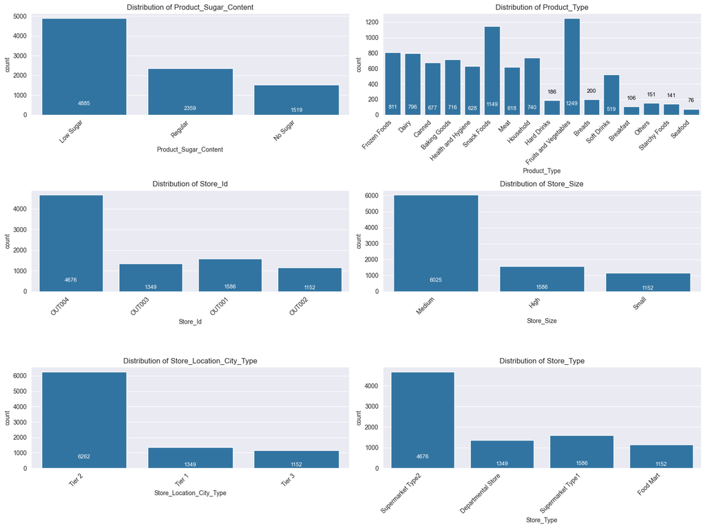

```python
# Plot figure size of 12x12
plt.figure(figsize=(16, 12))
total = len(dataset)

# iterate category features and plot count plot
for i, feature in enumerate(category_columns):
    # Plot setup: 3 rows × 2 columns = 6 subplots
    ax = plt.subplot(3,2, i + 1)
    sns.countplot(data=dataset, x=feature, ax=ax)

    # Add count labels to each bar
    for p in ax.patches:
        height = p.get_height()
        if height == 0:
            continue
        count = f'{int(height)}'
        label_x = p.get_x() + p.get_width() / 2.

        if height < 0.05 * total:  # Short bars = show label above the bar
            ax.text(
                label_x,
                height + (0.01 * total),
                count,
                color='black',
                fontsize=9,
                ha='center'
            )
        else:  # Tall bars = show label inside with white text
            ax.text(
                label_x,
                height * 0.1,
                count,
                color='white',
                fontsize=9,
                ha='center'
            )

    ax.set_title(f'Distribution of {feature}')
    ax.set_xticklabels(ax.get_xticklabels(), rotation=45, ha='right')

plt.tight_layout()
plt.show()
```

**Analysis:**

`Product_Sugar_Content`

- Low sugar dominates (4885, >50% of products).
- Regular (2359) and No sugar (1519) products are comparatively fewer.
- Product mix is skewed toward low-sugar items, making up more than half of all stocked products.

`Product_Type`

`Store_Id`

- OUT004 clearly carries the highest product variety with the highest product count of 4676.
- OUT001, OUT002, and OUT003 show relatively balanced distributions (1152–1586 each).

`Store_Size`

- Medium-sized stores drive majority of product availability compared to small and high-sized outlets.
- Medium-sized have 6025 products compared to High (1586) and Small (1152) stores

`Store_Location_City_Type`

- Tier 2 cities appear the main market focus, stocking most of the products
- Tier 2 stores hold the majority of the products i.e., 6262 while Tier 1 has 1349 and Tier 3 with 1152, substantially fewer

`Store_Type`

- 'Supermarket Type2' leads the product range with most products 4676.
- Supermarket Type1 (1586) and Departmental Stores (1349) are mid-range.
- Food Marts carry the least variety (1152).

### Target variable - Product_Store_Sales_Total Analysis

- Target variable is a numeric variable and will be analysed using stat summary, skewness, histogram and boxplot

```python
# Descriptive statistics of the target variable
dataset['Product_Store_Sales_Total'].describe()
```

```
count    8763.000000
mean     3464.003640
std      1065.630494
min        33.000000
25%      2761.715000
50%      3452.340000
75%      4145.165000
max      8000.000000
Name: Product_Store_Sales_Total, dtype: float64
```

```python
# Skewness of the target variable
dataset['Product_Store_Sales_Total'].skew()
```

```
np.float64(0.09202416922487767)
```

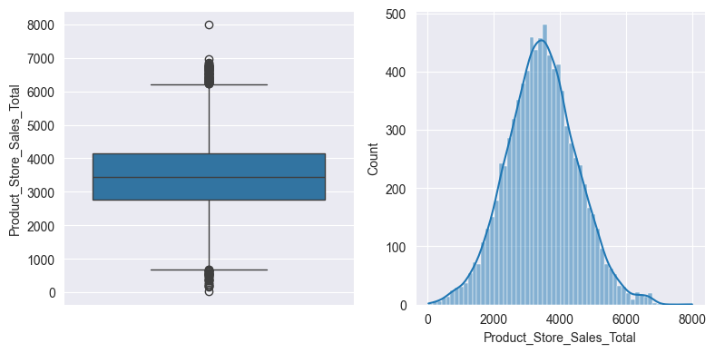

```python
#Boxplot and histogram plot of the target variable
plt.figure(figsize=(8,4))
plt.subplot(1, 2, 1)    # assign a subplot in the main plot
sns.boxplot(dataset['Product_Store_Sales_Total']) #boxplot for target variable
plt.subplot(1, 2, 2)    # assign a subplot in the main plot
sns.histplot(data=dataset['Product_Store_Sales_Total'], kde=True) #histplot for target variable
plt.tight_layout()
plt.show()
```

**Observations:**

- Mean is slightly greater than median. Distribution appears approximately symmetric to mildly right-skewed (a few high-value tails), not heavily skewed.
- Outliers exist but not extreme enough to mandate a log transform.
- Skewness statistic is 0.09 and also indicating log transformation may not be necessary

## Bivariate Analysis

### Numerical variables correlation (Heatmap)

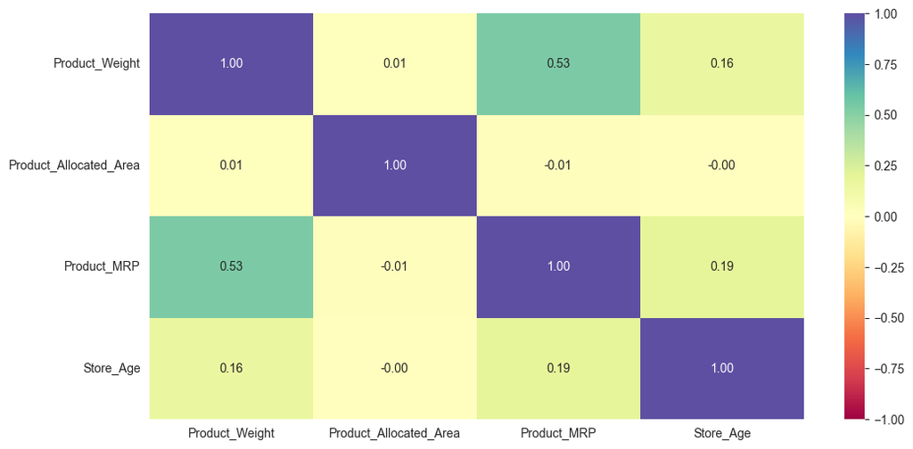

```python
# defining the size of the plot
plt.figure(figsize=(12, 6))

# plotting the heatmap for correlation
sns.heatmap(
    dataset[numeric_features].corr(),annot=True, vmin=-1, vmax=1, fmt=".2f", cmap="Spectral"
);
plt.show()
```

**Analysis:**

- `Product_Weight` and `Product_MRP` : Show a moderate positive correlation (0.53), suggesting that heavier products generally have higher retail prices.
- `Store_Age` : Exhibits a mild positive correlation with both `Product_MRP` (0.19) and `Product_Weight` (0.16), indicating that older stores tend to stock slightly heavier and higher-priced items, possibly due to broader or more premium product ranges.
- `Product_Allocated_Area` : Has almost no correlation with other numeric features, implying that shelf space allocation is independent of product weight, price, or store age.

### Numerical variables correlation with Product_Store_Sales_Total (Boxplot)

- Box plots will be used to summarize distribution shifts of numerical features across sales binned (from low to high).
- This helps identify whether higher sales are associated with higher or lower ranges of a feature while also highlighting variability and outliers.

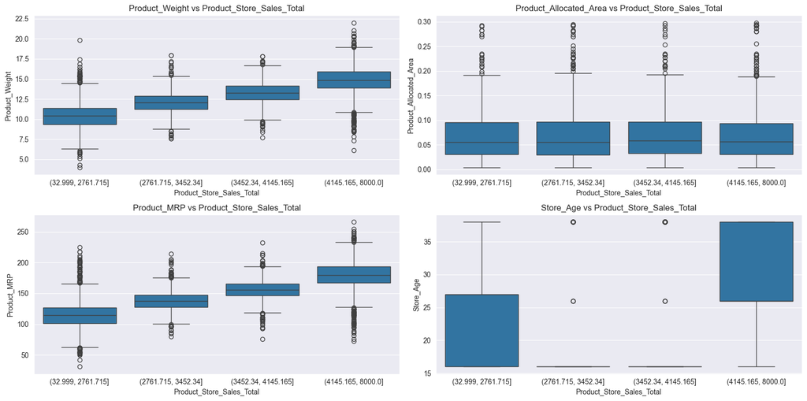

```python
# define the plot figure size
plt.figure(figsize=(16, 8))

# plotting the boxplots for each numerical feature against target
for i, feature in enumerate(numeric_features):
    plt.subplot(2, 2, i+1)    # assign a subplot in the main plot
    plt.title(f"{feature} vs Product_Store_Sales_Total")
    sns.boxplot(data=dataset, x=pd.qcut(dataset['Product_Store_Sales_Total'], q=4, duplicates='drop'),
                y=feature)    # binning target into quartiles for visualization

plt.tight_layout();   # to add spacing between plots
plt.show()
```

**Analysis**

1. `Product_Weight` vs `Product_Store_Sales_Total`
   - Higher sales totals tend to align with heavier products
   - Median product weight increases across sales bins.
2. `Product_Allocated_Area` vs `Product_Store_Sales_Total`
   - Distribution remains fairly stable across bins, suggesting shelf space allocation alone doesn't strongly differentiate sales.
3. `Product_MRP` vs `Product_Store_Sales_Total`
   - Clear upward trend can be seen
   - higher sales totals are associated with higher MRPs, indicating that premium-priced products contribute significantly to revenue.
4. `Store_Age` vs `Product_Store_Sales_Total`
   - Older stores are more represented in higher sales bins, reflecting possible customer loyalty and established presence.

### Categorical variables correlation with Product_Store_Sales_Total (Boxplot)

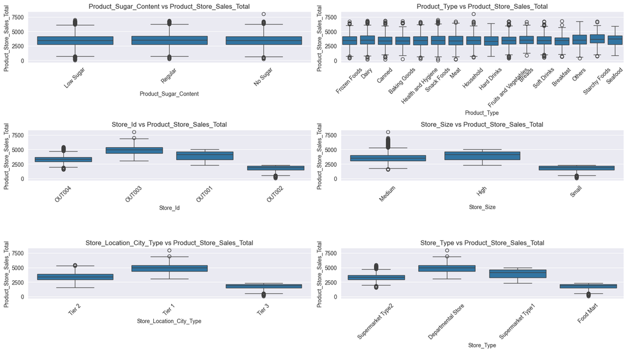

```python
plt.figure(figsize=(16, 9))

for i, feature in enumerate(category_columns):
    plt.subplot(3, 2, i+1)
    sns.boxplot(data=dataset, x=feature, y='Product_Store_Sales_Total')
    plt.title(f"{feature} vs Product_Store_Sales_Total")
    plt.xticks(rotation=45)

plt.tight_layout()
plt.show()
```

**BiVariate Analysis**

# **Data Preprocessing**

## Feature Engineering

Following are the feature engineering approaches that will be performed

### Categorical features:

- One-hot label encoded categorical columns:
  1. `Product_Sugar_Content`
  2. `Product_Type`
  3. `Store_Size`
  4. `Store_Location_City_Type`
  5. `Store_Type`
- Rationale for one-hot (not label/ordinal encoding):
  - Avoids introducing artificial order where business impact is not strictly monotonic.
  - Preserves flexibility for non-linear, category-specific effects.
  - Improves interpretability (each dummy directly attributable to a category).
  - Low/moderate cardinality so dimensionality increase is acceptable.
  - Prevents biased tree splits that could arise from arbitrary integer ranks.
  - Easier to extend if new categories appear (add new column without remapping codes).
- Categorical columns not considered for model:
  1. `Store_Id` : will not be used as categorical feature.
     - Rationale: It is a unique identifier for each store and does not carry inherent ordinal or numerical meaning. Including it could lead to overfitting, as the model might learn to associate specific store IDs with sales patterns that do not generalize beyond the training data.

**Note:** Outlier detection and treatment will be done in the next section

## Outlier detection and Treatment

### Outlier detection using boxplot

- Outlier detection of numerical features will be done by drawing box plots

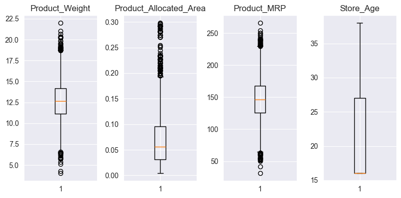

```python
# outlier detection using boxplot
plt.figure(figsize=(8, 4))
for i, variable in enumerate(numeric_features):
    plt.subplot(1, 4, i + 1)
    plt.boxplot(dataset[variable], whis=1.5)
    plt.tight_layout()
    plt.title(variable)

plt.show()
```

**Observations:**

- `Product_Weight`
  - Approximately symmetric with mild tails, non-negative values
  - The values will be left as is and will not be treated or dropped
- `Product_MRP`
  - Near-normal with a positive correlation to `Product_Store_Sales_Total` as seen earlier
  - They are also non-negative values
  - The values will be left as is and will not be treated or dropped. Mild capping at IQR can be done but not being done now for the smaller dataset
- `Product_Allocated_Area`
  - Right-skewed with outliers
  - The values can be log transformed to reduce skewness and impact of outliers.
    - log1p to be used to handle zeros as the values are near zero
- `Store_Age`
  - Raw Store_Age shows only four distinct values (derived from establishment years).
  - For better model learning and business interpretation, **convert into age bins** (e.g., New, Mid, Mature stores) instead of keeping as raw numeric.
  - This reduces noise, makes the feature categorical, and aligns with real business segmentation.

### Outlier treatment in `Product_Allocated_Area`

```
Original min/max: 0.004 0.298
Log min/max: 0.003992021269537453 0.26082461828189824
```

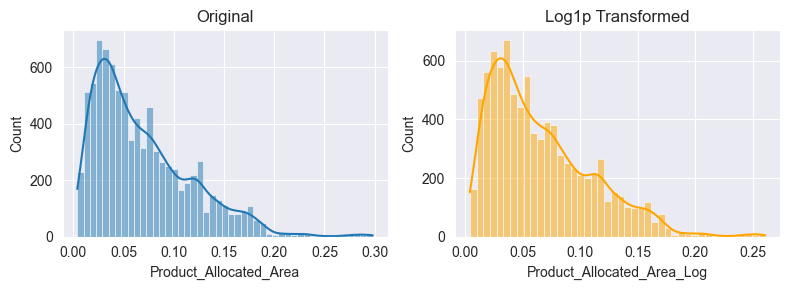

```python
# Log transform right-skewed Product_Allocated_Area (additive log1p: handles zeros)
dataset['Product_Allocated_Area_Log'] = np.log1p(dataset['Product_Allocated_Area'])

# Quick sanity check
print('Original min/max:', dataset['Product_Allocated_Area'].min(), dataset['Product_Allocated_Area'].max())
print('Log min/max:', dataset['Product_Allocated_Area_Log'].min(), dataset['Product_Allocated_Area_Log'].max())

# Optional: visualize the log transformation effect
fig, axes = plt.subplots(1,2, figsize=(8,3))
sns.histplot(dataset['Product_Allocated_Area'], ax=axes[0], kde=True)
axes[0].set_title('Original')
sns.histplot(dataset['Product_Allocated_Area_Log'], ax=axes[1], kde=True, color='orange')
axes[1].set_title('Log1p Transformed')
plt.tight_layout(); plt.show()
```

**Observations:**

- Log transformation is not making significant difference to the distribution
- Shape and skew visually remain unchanged.
- Value range is already <0.3; log1p(x) ≈ x for small `Product_Allocated_Area`.
- Max compressed only ~12–13% (0.298 → 0.2608);
- Adds redundant feature without clear variance stabilization.

Hence, the log transformed column will not be used for model building and will be dropped

```python
# Drop the log transformed column for Product_Allocated_Area
dataset.drop(columns=['Product_Allocated_Area_Log'], inplace=True)
```

### Binning `Store_Age` into bins

```python
# Define bins and labels (open-ended last bin for 50+ years)
bins = [0, 10, 20, 30, float("inf")]
labels = ["<10 Years", "10–20 Years", "20–30 Years", "30+ Years"]

# Create binned column
dataset["Store_Age_Binned"] = pd.cut(
    dataset["Store_Age"],
    bins=bins,
    labels=labels,
    right=False
)
```

```python
# Check result
print(dataset[["Store_Establishment_Year", "Store_Age_Binned"]].head(10))
```

```
   Store_Establishment_Year Store_Age_Binned
0                      2009      10–20 Years
1                      1999      20–30 Years
2                      1987        30+ Years
3                      1987        30+ Years
4                      1998      20–30 Years
5                      2009      10–20 Years
6                      1999      20–30 Years
7                      1999      20–30 Years
8                      1998      20–30 Years
9                      2009      10–20 Years
```

## Data preparation for Analysis

### Current dataset - top 5 records

```python
# print 5 records of the cleaned dataset
dataset.head()
```

|  | Product_Id | Product_Weight | Product_Sugar_Content | Product_Allocated_Area | Product_Type | Product_MRP | Store_Id | Store_Establishment_Year | Store_Size | Store_Location_City_Type | Store_Type | Product_Store_Sales_Total | Store_Age | Store_Age_Binned |
| --- | --- | --- | --- | --- | --- | --- | --- | --- | --- | --- | --- | --- | --- | --- |
| 0 | FD6114 | 12.66 | Low Sugar | 0.027 | Frozen Foods | 117.08 | OUT004 | 2009 | Medium | Tier 2 | Supermarket Type2 | 2842.40 | 16 | 10–20 Years |
| 1 | FD7839 | 16.54 | Low Sugar | 0.144 | Dairy | 171.43 | OUT003 | 1999 | Medium | Tier 1 | Departmental Store | 4830.02 | 26 | 20–30 Years |
| 2 | FD5075 | 14.28 | Regular | 0.031 | Canned | 162.08 | OUT001 | 1987 | High | Tier 2 | Supermarket Type1 | 4130.16 | 38 | 30+ Years |
| 3 | FD8233 | 12.10 | Low Sugar | 0.112 | Baking Goods | 186.31 | OUT001 | 1987 | High | Tier 2 | Supermarket Type1 | 4132.18 | 38 | 30+ Years |
| 4 | NC1180 | 9.57 | No Sugar | 0.010 | Health and Hygiene | 123.67 | OUT002 | 1998 | Small | Tier 3 | Food Mart | 2279.36 | 27 | 20–30 Years |

```python
# Redefine Numeric and Category columns needed for model building
numeric_features = [
    'Product_Weight',
    'Product_Allocated_Area',
    'Product_MRP'
]

category_columns =[
  'Product_Sugar_Content',
  'Product_Type',
  'Store_Size',
  'Store_Location_City_Type',
  'Store_Type',
  'Store_Age_Binned'
]
```

### Train, Validation and Test datasets

```python
# Define predictor matrix (X) using selected numeric and categorical features
X = dataset[numeric_features + category_columns]

# Define target variable
y = dataset['Product_Store_Sales_Total']
```

```python
# Data split into 2 parts : temporary and test
X_temp, X_test, y_temp, y_test = train_test_split(
    X, y, test_size=0.2, random_state=42
)

# Temporary set split into train and validation
X_train, X_val, y_train, y_val = train_test_split(
    X_temp, y_temp, test_size=0.2, random_state=42
)

# Create table of dataset shapes with y having 1 col
shapes = pd.DataFrame({
    'Dataset': ['X_train', 'y_train', 'X_val', 'y_val', 'X_test','y_test'],
    'Rows':   [X_train.shape[0], y_train.shape[0],
               X_val.shape[0], y_val.shape[0],
               X_test.shape[0], y_test.shape[0]],
    'Columns': [X_train.shape[1], 1,
                X_val.shape[1], 1,
                X_test.shape[1], 1]
})

print(shapes)
```

```
   Dataset  Rows  Columns
0  X_train  5608        9
1  y_train  5608        1
2    X_val  1402        9
3    y_val  1402        1
4   X_test  1753        9
5   y_test  1753        1
```

- The sizes are intact with 5608 + 1402 + 1753 summing up to initially observed 8763 records
- X has 9 columns as both ID columns `Product_Id` and `Store_Id` are not considered
- Y size is 1 reflecting the target column `Product_Store_Sales_Total`

### Pre-processor for encoding categorical features

- `make_column_transformer` step creates a preprocessing pipeline for the dataset by applying different transformations to numeric and categorical features.

```python
# Create a preprocessing pipeline for numerical and categorical features
preprocessor = make_column_transformer(
    (StandardScaler(), numeric_features),  # Scale numeric features to have mean equal to 0 and standard deviation equal to 1
    (OneHotEncoder(handle_unknown='ignore'), category_columns)  # Encode categorical features as one-hot vectors
)
```

# **Model Building**

## Model Evaluation Criterion

#### What does SuperKart want?

- SuperKart wants to accurately forecast the sales revenue of its outlets for the upcoming quarter.

#### Which metric to optimise for evaluation?

- Primary optimization metric: **Root Mean Squared Error (RMSE)**

**Why RMSE?**

1. **Business relevance**: Bigger mistakes on high-revenue items are costlier. RMSE penalizes large errors more, which aligns with minimizing stockouts/overstocks.
2. **Interpretability**: Expressed in the same units as sales, so errors can be directly explained to stakeholders (e.g., “average error ≈ ₹X”).
3. **Model fit**: Tree models (Random Forest, XGBoost) naturally optimize squared error, making RMSE the consistent choice.

**Other metrics:**

1. **MAE** (mean absolute error) will also be reported for robustness.
2. **MAPE** (percentage error) adds relative perspective but is unstable for low sales.
3. **R²** gives model fit but isn’t an optimization metric.

## Functions for Model Evaluation

```python
# function to compute adjusted R-squared
def adj_r2_score(predictors, targets, predictions):
    r2 = r2_score(targets, predictions)
    n = predictors.shape[0]
    k = predictors.shape[1]
    return 1 - ((1 - r2) * (n - 1) / (n - k - 1))


# function to compute different metrics to check performance of a regression model
def model_performance_regression(model, predictors, target):
    """
    Function to compute different metrics to check regression model performance

    model: regressor
    predictors: independent variables
    target: dependent variable
    """

    # predicting using the independent variables
    pred = model.predict(predictors)

    r2 = r2_score(target, pred)  # to compute R-squared
    adjr2 = adj_r2_score(predictors, target, pred)  # to compute adjusted R-squared
    rmse = np.sqrt(mean_squared_error(target, pred))  # to compute RMSE
    mae = mean_absolute_error(target, pred)  # to compute MAE
    mape = mean_absolute_percentage_error(target, pred)  # to compute MAPE

    # creating a dataframe of metrics
    df_perf = pd.DataFrame(
        {
            "RMSE": rmse,
            "MAE": mae,
            "R-squared": r2,
            "Adj. R-squared": adjr2,
            "MAPE": mape,
        },
        index=[0],
    )

    return df_perf
```

```python
# function to create a single DataFrame of training, testing performances
def model_performances(train, validation):

  #combine the dataframes across rows
  combined = pd.concat([train, validation],
                     axis=0,
                     keys=["Training", "Validation"])
  # drop the index
  combined.reset_index(level=1, drop=True)
  return combined
```

The ML models to be built can be any two out of the following:

1. Decision Tree
2. Bagging
3. Random Forest
4. AdaBoost
5. Gradient Boosting
6. XGBoost

## ML Algorithm choices for Model Building

Following 2 choices will be used for building the models, and fine-tuning them with hyper parameters

1. Random Forest Regressor
2. XGBoost Regressor

## Model 1 : Random Forest Regressor

### Model-1 Training Pipeline

```python
# Define base Random Forest model
model1 = RandomForestRegressor(random_state=42)

# Create pipeline with preprocessing and Random Forest model
model1_pipeline = make_pipeline(preprocessor, model1)

# Train the model pipeline on the training data
model1_pipeline.fit(X_train, y_train)
```

```
Pipeline(steps=[('columntransformer',
                 ColumnTransformer(transformers=[('standardscaler',
                                                  StandardScaler(),
                                                  ['Product_Weight',
                                                   'Product_Allocated_Area',
                                                   'Product_MRP']),
                                                 ('onehotencoder',
                                                  OneHotEncoder(handle_unknown='ignore'),
                                                  ['Product_Sugar_Content',
                                                   'Product_Type', 'Store_Size',
                                                   'Store_Location_City_Type',
                                                   'Store_Type',
                                                   'Store_Age_Binned'])])),
                ('randomforestregressor',
                 RandomForestRegressor(random_state=42))])
```

### Model-1 performance on train, validation

```python
# compute performance metrics on training data set
model1_train_perf = model_performance_regression(model1_pipeline, X_train, y_train)

# compute performance metrics on validation data
model1_val_perf = model_performance_regression(model1_pipeline, X_val, y_val)

# print and compare model performances for train and validation data
model1_performance = model_performances(model1_train_perf, model1_val_perf)
model1_performance
```

|  |  | RMSE | MAE | R-squared | Adj. R-squared | MAPE |
| --- | --- | --- | --- | --- | --- | --- |
| Training | 0 | 109.537658 | 41.544960 | 0.989489 | 0.989472 | 0.015690 |
| Validation | 0 | 283.551307 | 107.590238 | 0.927038 | 0.926567 | 0.040346 |

## Model 2 : XGBoost Regressor

### Model-2 Training Pipeline

```python
# Define base XGBoost Regressor model
model2 = XGBRegressor(random_state=42)

# Create pipeline with preprocessing and Random Forest model
model2_pipeline = make_pipeline(preprocessor, model2)

# Train the model pipeline on the training data
model2_pipeline.fit(X_train, y_train)
```

```
Pipeline(steps=[('columntransformer',
                 ColumnTransformer(transformers=[('standardscaler',
                                                  StandardScaler(),
                                                  ['Product_Weight',
                                                   'Product_Allocated_Area',
                                                   'Product_MRP']),
                                                 ('onehotencoder',
                                                  OneHotEncoder(handle_unknown='ignore'),
                                                  ['Product_Sugar_Content',
                                                   'Product_Type', 'Store_Size',
                                                   'Store_Location_City_Type',
                                                   'Store_Type',
                                                   'Store_Age_Binned'])])),
                ('xgbregressor...
                              feature_types=None, feature_weights=None,
                              gamma=None, grow_policy=None,
                              importance_type=None,
                              interaction_constraints=None, learning_rate=None,
                              max_bin=None, max_cat_threshold=None,
                              max_cat_to_onehot=None, max_delta_step=None,
                              max_depth=None, max_leaves=None,
                              min_child_weight=None, missing=nan,
                              monotone_constraints=None, multi_strategy=None,
                              n_estimators=None, n_jobs=None,
                              num_parallel_tree=None, ...))])
```

### Model-2 performance on train, validation

```python
# compute performance metrics on training data set
model2_train_perf = model_performance_regression(model2_pipeline, X_train, y_train)

# compute performance metrics on validation data
model2_val_perf = model_performance_regression(model2_pipeline, X_val, y_val)

# print and compare model performances for train and validation data
model2_performance = model_performances(model2_train_perf, model2_val_perf)
model2_performance
```

|  |  | RMSE | MAE | R-squared | Adj. R-squared | MAPE |
| --- | --- | --- | --- | --- | --- | --- |
| Training | 0 | 117.273537 | 58.852848 | 0.987951 | 0.987932 | 0.020035 |
| Validation | 0 | 304.136128 | 136.608427 | 0.916060 | 0.915518 | 0.050221 |

### Model-2 performance analysis

- **Overall fit**:
  - Validation R-squared = 0.916 (strong explanatory power) but lower than Model-1 Random Forest (≈0.93).
  - So, we can see that the baseline XGBoost underperforms Random Forest on unseen data.
- **Error magnitude:**
  - Validation RMSE ≈ 304 (vs 283 for Random Forest) and MAE ≈ 136 (vs 107 for Random ForestRF)
  - Higher absolute errors confirm weaker generalization in current default settings
- **Relative accuracy:**
  - Validation MAPE ≈ 5.0% (worse than RF ≈ 4.0%), indicating larger proportional errors, especially on lower / mid sales ranges.
- **Overfitting profile:**
  - Train RMSE 117 and Validation RMSE 304 (≈2.6× gap) shows variance, similar to RF’s ≈2.6× gap
  - Model is still overfitting but also not matching RF’s signal capture.
- **Bias vs variance:**
  - Higher Validation error plus higher training error (compared to RF) suggests both
    - (a) less capacity used / suboptimal hyperparameters
    - (b) some residual variance, hence tuning needed rather than immediate feature changes.
- **Adjusted R-squared and R-squared**
  - difference is negligible.
  - This indicates no unnecessary feature inflation; preprocessing remains appropriate.

## Overall : Model-1 and Model-2

- Random Forest currently outperforms XGBoost on accuracy and relative error, but both models show overfitting signs and will benefit from hyperparameter tuning.

# **Model Performance Improvement - Hyperparameter Tuning**

## Model 3 : Random Forest Regressor Hyper Param Tuned

### Model-3 : Training Pipeline

```python
# Define base Random Forest model
model3 = RandomForestRegressor(random_state=42)

# Create pipeline with preprocessing and Random Forest model
model3_pipeline = make_pipeline(preprocessor, model3)

# Grid of parameters to choose from
parameters = {
    'randomforestregressor__max_depth': [8,9,10,11],
    'randomforestregressor__max_features': ['sqrt', 0.7, 0.8],
    'randomforestregressor__n_estimators': [250, 300, 350],
    'randomforestregressor__min_samples_split': [8, 10, 12],
    'randomforestregressor__min_samples_leaf': [3, 5, 8]
}

# Run the grid search
model3_grid_obj = GridSearchCV(model3_pipeline,
                                parameters,
                                scoring='neg_root_mean_squared_error',
                                cv=5, n_jobs=-1)
model3_grid_obj.fit(X_train, y_train)

# Obtain the tuned model
# Note : fit again is not required as best_estimator_ is already fitted after GridSearchCV.
model3_tuned = model3_grid_obj.best_estimator_
model3_tuned
```

```
Pipeline(steps=[('columntransformer',
                 ColumnTransformer(transformers=[('standardscaler',
                                                  StandardScaler(),
                                                  ['Product_Weight',
                                                   'Product_Allocated_Area',
                                                   'Product_MRP']),
                                                 ('onehotencoder',
                                                  OneHotEncoder(handle_unknown='ignore'),
                                                  ['Product_Sugar_Content',
                                                   'Product_Type', 'Store_Size',
                                                   'Store_Location_City_Type',
                                                   'Store_Type',
                                                   'Store_Age_Binned'])])),
                ('randomforestregressor',
                 RandomForestRegressor(max_depth=11, max_features=0.8,
                                       min_samples_leaf=3, min_samples_split=8,
                                       n_estimators=350, random_state=42))])
```

### Model-3 : Fine-tuned params

```python
# Print attributes of the tuned RandomForestRegressor
print("n_estimators:", model3_tuned.named_steps['randomforestregressor'].n_estimators)
print("max_depth:", model3_tuned.named_steps['randomforestregressor'].max_depth)
print("max_features:", model3_tuned.named_steps['randomforestregressor'].max_features)
print("min_samples_split:", model3_tuned.named_steps['randomforestregressor'].min_samples_split)
print("min_samples_leaf:", model3_tuned.named_steps['randomforestregressor'].min_samples_leaf)
```

```
n_estimators: 350
max_depth: 11
max_features: 0.8
min_samples_split: 8
min_samples_leaf: 3
```

### Model-3 : Performance on train, validation

```python
# compute performance metrics on training data set
model3_tuned_train_perf = model_performance_regression(model3_tuned, X_train, y_train)

# compute performance metrics on validation data
model3_tuned_val_perf = model_performance_regression(model3_tuned, X_val, y_val)

# print and compare model performances for train and validation data
model3_performance = model_performances(model3_tuned_train_perf, model3_tuned_val_perf)
model3_performance
```

|  |  | RMSE | MAE | R-squared | Adj. R-squared | MAPE |
| --- | --- | --- | --- | --- | --- | --- |
| Training | 0 | 219.468736 | 86.271635 | 0.957803 | 0.957735 | 0.032972 |
| Validation | 0 | 274.960000 | 107.749367 | 0.931393 | 0.930949 | 0.041200 |

### Model-3 performance analysis

- **Generalization improved:**
  - Validation RMSE reduced to ~275 from baseline 283.5 (~3% improvement) and R-squared increased slightly (0.931 vs 0.927).
- **Controlled overfitting:**
  - Train RMSE rose from 109.5 (baseline) to 219.4 (intentional regularization)
  - Train:Validation RMSE ratio moved from ~0.38 to ~0.79, indicating a narrower gap and better variance control.
- **Stability retained:**
  - Validation MAPE (≈4.0%) essentially unchanged vs baseline (≈4.0%), showing relative accuracy preserved while reducing variance.
- **Parameter effects:**
  - Deeper but regularized trees (max_depth=11 with min_samples_leaf=3, min_samples_split=8, max_features=0.8, more trees n_estimators=350) increased bias slightly (higher train error) to gain modest Validation uplift.
- **Trade-off acceptable:**
  - Small absolute gain but healthier bias–variance profile

**Conclusion:** Overall tuned RandomForestRegressor model performed over baseline RandomForestRegressor.

## Model 4 : XGBoost Regressor Hyper Param Tuned

### Model-4: Training Pipeline

```python
# Define base XGBoost Regressor model
model4 = XGBRegressor(random_state=42)

# Create pipeline with preprocessing and Random Forest model
model4_pipeline = make_pipeline(preprocessor, model4)

# Grid of parameters to choose from
xgb_parameters = {
    'xgbregressor__n_estimators': [300, 500, 600, 700],
    'xgbregressor__max_depth': [5, 6, 7],
    'xgbregressor__colsample_bytree': [0.6, 0.7, 0.8],
    'xgbregressor__colsample_bylevel': [0.6, 0.7, 0.8],
    'xgbregressor__learning_rate': [0.1, 0.05, 0.03],
    'xgbregressor__reg_lambda': [1, 2, 4],
    'xgbregressor__subsample': [0.7, 0.8, 0.9]
}

# Run the grid search
model4_tuned_grid_obj = GridSearchCV(model4_pipeline,
                                xgb_parameters,
                                scoring='neg_root_mean_squared_error',
                                cv=5, n_jobs=-1)
model4_tuned_grid_obj.fit(X_train, y_train)

# Obtain the tuned model
# Note : fit again is not required as `best_estimator_` is already fitted after GridSearchCV.
model4_tuned = model4_tuned_grid_obj.best_estimator_

# print model4_tuned
model4_tuned
```

```
Pipeline(steps=[('columntransformer',
                 ColumnTransformer(transformers=[('standardscaler',
                                                  StandardScaler(),
                                                  ['Product_Weight',
                                                   'Product_Allocated_Area',
                                                   'Product_MRP']),
                                                 ('onehotencoder',
                                                  OneHotEncoder(handle_unknown='ignore'),
                                                  ['Product_Sugar_Content',
                                                   'Product_Type', 'Store_Size',
                                                   'Store_Location_City_Type',
                                                   'Store_Type',
                                                   'Store_Age_Binned'])])),
                ('xgbregressor...
                              feature_types=None, feature_weights=None,
                              gamma=None, grow_policy=None,
                              importance_type=None,
                              interaction_constraints=None, learning_rate=0.03,
                              max_bin=None, max_cat_threshold=None,
                              max_cat_to_onehot=None, max_delta_step=None,
                              max_depth=7, max_leaves=None,
                              min_child_weight=None, missing=nan,
                              monotone_constraints=None, multi_strategy=None,
                              n_estimators=300, n_jobs=None,
                              num_parallel_tree=None, ...))])
```

### Model-4: Fine-tuned params

```python
# Print attributes of the tuned XGBoostRegressor
print("n_estimators:", model4_tuned.named_steps['xgbregressor'].n_estimators)
print("max_depth:", model4_tuned.named_steps['xgbregressor'].max_depth)
print("colsample_bytree:", model4_tuned.named_steps['xgbregressor'].colsample_bytree)
print("colsample_bylevel:", model4_tuned.named_steps['xgbregressor'].colsample_bylevel)
print("learning_rate:", model4_tuned.named_steps['xgbregressor'].learning_rate)
print("reg_lambda:", model4_tuned.named_steps['xgbregressor'].reg_lambda)
print("subsample:", model4_tuned.named_steps['xgbregressor'].subsample)
```

```
n_estimators: 300
max_depth: 7
colsample_bytree: 0.8
colsample_bylevel: 0.8
learning_rate: 0.03
reg_lambda: 2
subsample: 0.9
```

### Model-4 : Performance on train, validation

```python
# compute performance metrics on training data set
model4_tuned_train_perf = model_performance_regression(model4_tuned, X_train, y_train)

# compute performance metrics on validation data
model4_tuned_val_perf = model_performance_regression(model4_tuned, X_val, y_val)

# print and compare model performances for train and validation data
model4_performance = model_performances(model4_tuned_train_perf, model4_tuned_val_perf)
model4_performance
```

|  |  | RMSE | MAE | R-squared | Adj. R-squared | MAPE |
| --- | --- | --- | --- | --- | --- | --- |
| Training | 0 | 194.947124 | 79.537925 | 0.966706 | 0.966652 | 0.029356 |
| Validation | 0 | 283.135407 | 114.107511 | 0.927252 | 0.926782 | 0.043176 |

### Model-4 performance analysis

- **Overall fit:**
  - Validation R-squared = 0.927 (strong) but lower than tuned Random Forest (≈0.931)
  - no lift over tuned Random Forest.
- **Generalization:**
  - Validation RMSE 283.1 is higher (worse) than tuned Random Forest (274.9) and close to baseline Random Forest (≈283)
  - Tuned XGB did not improve error.
- **Variance indication:**
  - Train RMSE 194 vs Validation 283 (ratio ≈0.68) shows a larger gap than tuned Random Forest (≈0.79).
  - This implies comparatively higher variance / residual overfitting.
- **Relative error:**
  - Validation MAPE 4.31% higher than tuned Random Forest (~4.0%). Proportional accuracy has slightly degraded.
- **Bias–variance trade:**
  - Lower train error than tuned Random Forest (194 vs 219) but worse Validation error—suggests additional regularization
  - Fine-tuning further with lambda, max_depth or use early stopping could help.

## Overall : Model-3 and Model-4

**Conclusion:** XGB Regressor tuned underperforms compared to RandomForest tuned

# **Model Performance Comparison, Final Model Selection, and Serialization**

## Training performance comparison

- we will compare the performance of all models on the training dataset

```python
# create a combined dataframe of training performances of all models
models_train_comp_df = pd.concat([
    model1_train_perf.T,
    model2_train_perf.T,
    model3_tuned_train_perf.T,
    model4_tuned_train_perf.T
    ],axis=1,
)

# Add column names corresponding to the models
models_train_comp_df.columns = [
    "Random Forest Regressor",
    "XGBoost Regressor",
    "Random Forest Regressor Tuned",
    "XGBoost Regressor Tuned"
]

# print the model performance on training data
print("Training performance comparison:")
models_train_comp_df
```

```
Training performance comparison:
```

|  | Random Forest Regressor | XGBoost Regressor | Random Forest Regressor Tuned | XGBoost Regressor Tuned |
| --- | --- | --- | --- | --- |
| RMSE | 109.537658 | 117.273537 | 219.468736 | 194.947124 |
| MAE | 41.544960 | 58.852848 | 86.271635 | 79.537925 |
| R-squared | 0.989489 | 0.987951 | 0.957803 | 0.966706 |
| Adj. R-squared | 0.989472 | 0.987932 | 0.957735 | 0.966652 |
| MAPE | 0.015690 | 0.020035 | 0.032972 | 0.029356 |

## Validation performance comparison

```python
# create a combined dataframe of valing performances of all models
models_val_comp_df = pd.concat([
    model1_val_perf.T,
    model2_val_perf.T,
    model3_tuned_val_perf.T,
    model4_tuned_val_perf.T
    ],axis=1,
)

# Add column names corresponding to the models
models_val_comp_df.columns = [
    "Random Forest Regressor",
    "XGBoost Regressor",
    "Random Forest Regressor Tuned",
    "XGBoost Regressor Tuned"
]

# print the model performance on validation data
print("Validation performance comparison:")
models_val_comp_df
```

```
Validation performance comparison:
```

|  | Random Forest Regressor | XGBoost Regressor | Random Forest Regressor Tuned | XGBoost Regressor Tuned |
| --- | --- | --- | --- | --- |
| RMSE | 283.551307 | 304.136128 | 274.960000 | 283.135407 |
| MAE | 107.590238 | 136.608427 | 107.749367 | 114.107511 |
| R-squared | 0.927038 | 0.916060 | 0.931393 | 0.927252 |
| Adj. R-squared | 0.926567 | 0.915518 | 0.930949 | 0.926782 |
| MAPE | 0.040346 | 0.050221 | 0.041200 | 0.043176 |

## Best Model Selection

```python
# print difference in model performance on train and validation data w.r.t RMSE
(models_train_comp_df - models_val_comp_df).iloc[0]
```

```
Random Forest Regressor         -174.013648
XGBoost Regressor               -186.862591
Random Forest Regressor Tuned    -55.491264
XGBoost Regressor Tuned          -88.188283
Name: RMSE, dtype: float64
```

**Observations:**

- **Overfitting:**
  - RMSE 'train to test' gaps (absolute values) indicate overfitting severity across all models with 'Tuned Random Forest Regressor' having the smallest gap of 55
  - Others have,
    - Baseline RandomForest ~=174
    - Baseline XGB ~=186 (highest)
    - Tuned XGB ~=88 (improved)
- **Generalization:**
  - Smallest gap in Tuned Random Forest Regressor implies it has the best generalization among the 4 models
  - Variance in Tuned random forest substantially reduced compared to both baselines and tuned XGB.
- **Predictive Accuracy:**
  - Tuned RandomForest also has the lowest test RMSE and highest test R-squared among the four (seen in earlier comparison tables), confirming superior predictive accuracy.
- **More:**
  - Tuned XGB still shows a larger gap (≈88) and higher test error, offering no performance lift over tuned Random Forest.

**Conclusion:** '

- Tuned Random Forest Regressor (Model 3)' selected as the best model for serialization and deployment
- It has the best balance of accuracy and generalization among the 4 models.

## Serialization : Best Model

```python
# Create a folder for storing the files needed for web app deployment. Serialized Model will be stored here
os.makedirs("backend_files", exist_ok=True)
```

```python
# Define the file path to save (serialize) the trained model along with the data preprocessing steps
saved_model_path = "backend_files/superkart_sales_revenue_prediction_model_v1_0.joblib"
```

```python
# Save the best model selected i.e., Random Forest Regressor Tuned model pipeline using joblib
joblib.dump(model3_tuned, saved_model_path)
print(f"Random Forest Regressor Tuned Model saved successfully at {saved_model_path}")
```

```
Random Forest Regressor Tuned Model saved successfully at backend_files/superkart_sales_revenue_prediction_model_v1_0.joblib
```

## Load : Serialized Model

```python
# Load the saved model pipeline from the file
saved_model = joblib.load("backend_files/superkart_sales_revenue_prediction_model_v1_0.joblib")
# Confirm the model is loaded
print("Random Forest Regressor Tuned Model loaded successfully.")
```

```
Random Forest Regressor Tuned Model loaded successfully.
```

## Predict: Using saved Best model on test data

```python
# compute performance metrics on test data using the saved model
saved_model_test_perf = model_performance_regression(saved_model, X_test, y_test)
# print model performance on test data
saved_model_test_perf
```

|  | RMSE | MAE | R-squared | Adj. R-squared | MAPE |
| --- | --- | --- | --- | --- | --- |
| 0 | 278.492986 | 113.394723 | 0.932027 | 0.931676 | 0.041087 |

```python
# print best model performance seen earlier on validation data
model3_tuned_val_perf
```

|  | RMSE | MAE | R-squared | Adj. R-squared | MAPE |
| --- | --- | --- | --- | --- | --- |
| 0 | 274.96 | 107.749367 | 0.931393 | 0.930949 | 0.0412 |

## Best Model Performance on unseen test data

**Interpretation:**

- Generalization is strong: only minor drift in absolute error metrics; no material overfitting.
- Slight MAE increase suggests a few mid-range deviations; not systematic.
- Stable (even marginally improved) R² + lower MAPE confirms robustness.

**Conclusion:**

- Performance on unseen test data closely matches validation
- Model is reliable for deployment
- No immediate retraining needed

# **Deployment - Backend**

## Setting up a Hugging Face Docker Space for the Backend

- Creation of 'Hugging Face Docker Space' for deploying the backend will be automated using the Hugging Face Hub API.

### Login to Hugging Face

```python
# Import the login function from the huggingface_hub library
from huggingface_hub import login

# Login to your Hugging Face account using your access token
# login will prompt the HF token. For security purpose not directly provided in codes
login()

# Import the create_repo function from the huggingface_hub library
from huggingface_hub import create_repo
```

```python
# Check if logged in
# Import the whoami function from the huggingface_hub library
from huggingface_hub import whoami

# print the username if logged in
try:
    user_info = whoami()
    print(f"Logged in as: {user_info['name']}")
except:
    print("Not logged in")
```

```
Logged in as: nsriram78
```

### Create the backend docker repo space

```python
# Import the create_repo function from the huggingface_hub library
from huggingface_hub import create_repo

# Try to create the repository for the Hugging Face Space
try:
    create_repo("SuperKartRevenuePredictionBackend",  # backend space name
        repo_type="space",  # Repository type is "space"
        space_sdk="docker",  # Space SDK is "docker"
        private=False  # Creates as public space
    )
except Exception as e:
    # Handle potential errors during repository creation
    if "RepositoryAlreadyExistsError" in str(e):
        print("Repository already exists. Skipping creation.")
    else:
        print(f"Error creating repository: {e}")
```

## Flask Web Framework

```python
%%writefile backend_files/app.py
# Import necessary libraries
import joblib  # For loading the serialized model
import pandas as pd  # For data manipulation
from flask import Flask, request, jsonify  # For creating the Flask API
from datetime import datetime  # added for dynamic current year

# Initialize the Flask application
sales_revenue_predictor_api = Flask("SuperKart Sales Revenue Predictor")

# Load the trained machine learning model
model = joblib.load("superkart_sales_revenue_prediction_model_v1_0.joblib")

# Define a route for the home page (GET request)
@sales_revenue_predictor_api.get('/')
def home():
    """
    This function handles GET requests to the root URL ('/') of the API.
    It returns a simple welcome message.
    """
    return "Welcome to the SuperKart Product Sales Revenue Prediction API !"

# Define an endpoint for single product sales revenue prediction (POST request)
@sales_revenue_predictor_api.post('/v1/revenue')
def predict_sales_revenue():
    """
    This function handles POST requests to the '/v1/revenue' endpoint.
    It expects a JSON payload containing property details and returns
    the predicted product sales revenue as a JSON response.
    """
    # Get the JSON data from the request body
    property_data = request.get_json()

    # Extract relevant features from the JSON data
    sample = {
        'Product_Weight': property_data['Product_Weight'],
        'Product_Sugar_Content': property_data['Product_Sugar_Content'],
        'Product_Allocated_Area': property_data['Product_Allocated_Area'],
        'Product_Type': property_data['Product_Type'],
        'Product_MRP': property_data['Product_MRP'],
        'Store_Size': property_data['Store_Size'],
        'Store_Location_City_Type': property_data['Store_Location_City_Type'],
        'Store_Type': property_data['Store_Type'],
        'Store_Establishment_Year': property_data['Store_Establishment_Year']
    }

    # Convert the extracted data into a Pandas DataFrame
    record_input_data = pd.DataFrame([sample])

    # Compute Store_Age
    current_year_value = datetime.now().year
    record_input_data['Store_Age'] = current_year_value - record_input_data['Store_Establishment_Year']

    # Define bins and labels (open-ended last bin for 50+ years)
    age_bins = [0, 10, 20, 30, float("inf")]
    age_labels = ["<10 Years", "10–20 Years", "20–30 Years", "30+ Years"]

    # Create binned column
    record_input_data["Store_Age_Binned"] = pd.cut(
        record_input_data["Store_Age"],
        bins=age_bins,
        labels=age_labels,
        right=False
    )

    # Make prediction (get revenue)
    predicted_store_revenue = model.predict(record_input_data)[0]

    # Convert predicted_price to Python float
    predicted_store_revenue = round(float(predicted_store_revenue), 2)
    # When we send this value directly within a JSON response, Flask's jsonify function encounters a datatype error

    # Return the actual price
    return jsonify({'Predicted Product_Store_Sales_Total': predicted_store_revenue})


# Define an endpoint for batch prediction (POST request)
@sales_revenue_predictor_api.post('/v1/revenuebatch')
def predict_sales_revenue_batch():
    """
    This function handles POST requests to the '/v1/revenuebatch' endpoint.
    It expects a CSV file containing property details for multiple properties
    and returns the predicted product sales revenue as a dictionary in the JSON response.
    """
    # Get the uploaded CSV file from the request
    file = request.files['file']

    # Read the CSV file into a Pandas DataFrame
    csv_input_data = pd.read_csv(file)

    # Compute Store_Age
    current_year_value = datetime.now().year
    csv_input_data['Store_Age'] = current_year_value - csv_input_data['Store_Establishment_Year']
    # Define bins and labels (open-ended last bin for 50+ years)
    age_bins = [0, 10, 20, 30, float("inf")]
    age_labels = ["<10 Years", "10–20 Years", "20–30 Years", "30+ Years"]

    # Create binned column
    csv_input_data["Store_Age_Binned"] = pd.cut(
        csv_input_data["Store_Age"],
        bins=age_bins,
        labels=age_labels,
        right=False
    )

    # Make predictions for all properties in the DataFrame (get log_prices)
    predicted_store_revenues = model.predict(csv_input_data).tolist()

    # Create a dictionary of predictions with product IDs as keys
    if 'Product_Id' not in csv_input_data.columns:
        return jsonify({"error": "Input file must contain a 'Product_Id' column"}), 400

    # Create a dictionary of predictions with Product IDs as keys
    product_ids = csv_input_data['Product_Id'].tolist()  # Assuming 'Product_Id' is the property ID column
    output_dict = dict(zip(product_ids, predicted_store_revenues))  # Use actual prices

    # Return the predictions dictionary as a JSON response
    return jsonify(output_dict)

# Run the Flask application in debug mode if this script is executed directly
if __name__ == '__main__':
    sales_revenue_predictor_api.run(debug=True)
```

```
Writing backend_files/app.py
```

## Dependencies File

```python
%%writefile backend_files/requirements.txt
pandas==2.3.0
numpy==2.0.2
scikit-learn==1.6.1
xgboost==3.0.2
joblib==1.5.0
Werkzeug==3.1.3
flask==3.1.2
gunicorn==23.0.0
requests==2.32.3
uvicorn==0.34.2
streamlit==1.49.1
```

```
Writing backend_files/requirements.txt
```

## Dockerfile

```python
%%writefile backend_files/Dockerfile
FROM python:3.12-slim

# Set the working directory inside the container
WORKDIR /app

# Copy all files from the current directory to the container's working directory
COPY . .

# Install dependencies from the requirements file without using cache to reduce image size
RUN pip install --no-cache-dir --upgrade -r requirements.txt

# Define the command to start the application using Gunicorn with 4 worker processes
# - `-w 4`: Uses 4 worker processes for handling requests
# - `-b 0.0.0.0:7860`: Binds the server to port 7860 on all network interfaces
# - `app:app`: Runs the Flask app (assuming `app.py` contains the Flask instance named `app`)
CMD ["gunicorn", "-w", "4", "-b", "0.0.0.0:7860", "app:sales_revenue_predictor_api"]
```

```
Writing backend_files/Dockerfile
```

## Uploading Files to Hugging Face Space (Docker Space)

```python
# for hugging face space authentication to upload files
from huggingface_hub import HfApi

repo_id = "nsriram78/SuperKartRevenuePredictionBackend"  # HuggingFace space id

# Initialize the API
api = HfApi()

# Upload Streamlit app files stored in the folder called backend_files
api.upload_folder(
    folder_path="backend_files",  # Local folder path
    repo_id=repo_id,  # Hugging face space id
    repo_type="space",  # Hugging face repo type "space"
)
```

```
CommitInfo(commit_url='https://huggingface.co/spaces/nsriram78/SuperKartRevenuePredictionBackend/commit/2f7294aeb5f7b9811d748e9d9ee199ac90587ea3', commit_message='Upload folder using huggingface_hub', commit_description='', oid='2f7294aeb5f7b9811d748e9d9ee199ac90587ea3', pr_url=None, repo_url=RepoUr…
```

## Testing Backend deployment (Flask API)

- We will test the backend API separately as it is decoupled from the frontend and deployed separately

```python
# Set the model root URL to the deployed backend space URL
model_root_url = "https://nsriram78-SuperKartRevenuePredictionBackend.hf.space/"  # Base URL of the deployed backend in hugging face

#copy the csv data to a dataframe
app_test_dataset = superkart_data.copy()
```

### Test POST /v1/revenue API

```python
# Complete URL for single prediction endpoint
single_prediction_url = model_root_url + "/v1/revenue"

# convert the first record in X_test to a JSON for sending as payload
payload = app_test_dataset.head(1).to_dict(orient="records")[0]

# print the payload
print(payload)

# Sending a POST request to the model endpoint with the test payload
response = requests.post(single_prediction_url, json=payload)

# Check if request was successful
if response.status_code == 200:
    print("\nResponse received : ")
    print(response.json())   # Print parsed JSON response
else:
    print(f"Error {response.status_code}: {response.text}")
```

```
{'Product_Id': 'FD6114', 'Product_Weight': 12.66, 'Product_Sugar_Content': 'Low Sugar', 'Product_Allocated_Area': 0.027, 'Product_Type': 'Frozen Foods', 'Product_MRP': 117.08, 'Store_Id': 'OUT004', 'Store_Establishment_Year': 2009, 'Store_Size': 'Medium', 'Store_Location_City_Type': 'Tier 2', 'Store…

Response received :
{'Predicted Product_Store_Sales_Total': 2889.13}
```

**Observations:**

- We can observe the Single Record API working well
- We can notice that the predicted value 2889.13 is close to the actual value of 2842.4

### Test POST /v1/revenuebatch API

```python
# Take only the first 25 records
batch_payload = app_test_dataset.head(25)

# Save to CSV
batch_payload.to_csv("batch_test.csv", index=False)

# Keep product IDs and actual sales for comparison
actual_revenues = batch_payload[['Product_Id', 'Product_Store_Sales_Total']].copy()

# Complete URL for batch prediction endpoint
batch_prediction_url = model_root_url + "/v1/revenuebatch"

# Send the CSV file to the batch API endpoint
with open("batch_test.csv", "rb") as f:
    response = requests.post(batch_prediction_url, files={"file": f})

# Check response
if response.status_code == 200:
    predictions = response.json()

    # Convert predictions dict to DataFrame
    pred_df = pd.DataFrame(list(predictions.items()), columns=['Product_Id', 'Predicted Product_Store_Sales_Total'])

    # Merge actual_revenues with predictions
    comparison = actual_revenues.merge(pred_df, on='Product_Id', how='left')

    # Print the comparison
    print(comparison.head(20))  # show first 20 rows for quick check

else:
    print(f"Error {response.status_code}: {response.text}")
```

```
   Product_Id  Product_Store_Sales_Total  Predicted Product_Store_Sales_Total
0      FD6114                    2842.40                          2889.127817
1      FD7839                    4830.02                          4926.985808
2      FD5075                    4130.16                          4081.480744
3      FD8233                    4132.18                          4048.350404
4      NC1180                    2279.36                          2114.877796
5      FD5680                    2629.15                          2637.742359
6      FD5484                    5081.14                          5074.953371
7      NC5885                    4494.62                          4464.796989
8      FD1961                    1684.82                          1696.676795
9      NC6657                    2531.30                          2611.398431
10     DR2699                    3385.46                          3383.085370
11     FD6027                    3123.19                          3107.600245
12     FD8553                    3660.82                          3726.467496
13     FD5276                    3635.50                          3671.430858
14     FD1231                    3587.27                          3561.843956
15     FD1387                    3776.76                          3719.698012
16     NC1071                    2839.53                          2803.757419
17     FD2625                    3328.99                          3331.700866
18     FD4982                    4347.91                          4393.450895
19     NC7289                    3529.29                          3565.205229
```

## Hugging Face Backend Space Information

1. Backend Space URL: https://huggingface.co/spaces/nsriram78/SuperKartRevenuePredictionBackend
2. API endpoint URL
   - for single prediction: https://nsriram78-SuperKartRevenuePredictionBackend.hf.space/v1/revenue
   - for batch prediction: https://nsriram78-SuperKartRevenuePredictionBackend.hf.space/v1/revenuebatch

```
## Working backend app screenshot
```

[figure not shown]

# **Deployment - Frontend**

## Create the frontend docker repo space

```python
# Create the frontend repository for the Hugging Face Space
try:
    create_repo("SuperKartRevenuePredictionFrontend",  # backend space name
        repo_type="space",  # Repository type is "space"
        space_sdk="docker",  # Space SDK is "docker"
        private=False  # Creates as public space
    )
except Exception as e:
    # Handle potential errors during repository creation
    if "RepositoryAlreadyExistsError" in str(e):
        print("Repository already exists. Skipping creation.")
    else:
        print(f"Error creating repository: {e}")
```

## Create frontend_files directory

```python
# Create a folder for storing the files needed for frontend UI deployment
os.makedirs("frontend_files", exist_ok=True)

# Create a folder for storing the streamlit config
os.makedirs("frontend_files/.streamlit", exist_ok=True)
```

## Streamlit for Interactive UI

```python
%%writefile frontend_files/app.py
import streamlit as st
import pandas as pd
import requests
from datetime import datetime

import os
# force config dir inside repo
os.environ["STREAMLIT_CONFIG_DIR"] = os.path.join(os.getcwd(), ".streamlit")

# --- Page Config ---
st.set_page_config(
    page_title="SuperKart Product Sales Revenue Predictor",
    page_icon="🛒",
    layout="centered",
)

# --- Title ---
st.title("🛒 SuperKart Product Sales Revenue Predictor")
st.markdown("Enter product and store details below to predict sales revenue, or upload a CSV for batch predictions.")

# --- Layout for Product + Store Info ---
st.header("📦 Product Information")
col1, col2 = st.columns(2)

with col1:
    product_weight = st.number_input("Product Weight", min_value=0.0, step=0.01)
    product_sugar_content = st.selectbox("Product Sugar Content", ["Low Sugar", "Regular", "No Sugar"])
    product_allocated_area = st.number_input("Product Allocated Area", min_value=0.0, step=0.001)

with col2:
    product_type = st.selectbox(
        "Product Type",
        ["Meat", "Snack Foods", "Hard Drinks", "Dairy", "Canned", "Soft Drinks",
         "Health and Hygiene", "Baking Goods", "Bread", "Breakfast", "Frozen Foods",
         "Fruits and Vegetables", "Household", "Seafood", "Starchy Foods", "Others"]
    )
    product_mrp = st.number_input("Product MRP", min_value=0.0, step=0.01)

st.header("🏬 Store Information")
col3, col4 = st.columns(2)

with col3:
    store_establishment_year = st.number_input(
        "Store Establishment Year", min_value=1980, max_value=datetime.now().year, step=1
    )
    store_size = st.selectbox("Store Size", ["Small", "Medium", "High"])

with col4:
    store_location_city_type = st.selectbox("Store Location City Type", ["Tier 1", "Tier 2", "Tier 3"])
    store_type = st.selectbox("Store Type", ["Departmental Store", "Supermarket Type1", "Supermarket Type2", "Food Mart"])

# --- Build Input Data ---
input_data = pd.DataFrame([{
    "Product_Weight": product_weight,
    "Product_Sugar_Content": product_sugar_content,
    "Product_Allocated_Area": product_allocated_area,
    "Product_Type": product_type,
    "Product_MRP": product_mrp,
    "Store_Establishment_Year": store_establishment_year,
    "Store_Size": store_size,
    "Store_Location_City_Type": store_location_city_type,
    "Store_Type": store_type
}])

# --- Prediction Button ---
st.markdown("---")
if st.button("🔮 Predict Sales Revenue"):
    response = requests.post(
        "https://nsriram78-SuperKartRevenuePredictionBackend.hf.space/v1/revenue",
        json=input_data.to_dict(orient="records")[0]
    )
    if response.status_code == 200:
        prediction = response.json()["Predicted Product_Store_Sales_Total"]
        st.metric(label="Predicted Product Sales Revenue", value=f"{prediction:,.2f}")
    else:
        st.error("⚠️ Error making prediction. Please try again.")

# --- Batch Prediction Section ---
st.markdown("---")
st.header("📂 Batch Prediction")

with st.form("batch_form"):
    uploaded_file = st.file_uploader("Upload CSV file for batch prediction", type=["csv"])
    submit_button = st.form_submit_button("🚀 Predict Batch")

if submit_button and uploaded_file is not None:
    response = requests.post(
        "https://nsriram78-SuperKartRevenuePredictionBackend.hf.space/v1/revenuebatch",
        files={"file": uploaded_file}
    )
    if response.status_code == 200:
        predictions = response.json()
        st.success("✅ Batch predictions completed!")
        st.dataframe(pd.DataFrame(list(predictions.items()), columns=["Product_Id", "Predicted Sales Revenue"]))
    else:
        st.error("⚠️ Error making batch prediction.")
```

```
Writing frontend_files/app.py
```

## Dependencies File

```python
%%writefile frontend_files/requirements.txt
pandas==2.3.0
requests==2.32.3
streamlit==1.49.1
```

```
Writing frontend_files/requirements.txt
```

## DockerFile

```python
%%writefile frontend_files/Dockerfile
# Use a minimal base image with Python 3.9 installed
FROM python:3.12-slim

# Set the working directory inside the container to /app
WORKDIR /app

# Copy all files from the current directory on the host to the container's /app directory
COPY . .

# Enable Streamlit to use a writable folder for its config (like the working directory):
ENV STREAMLIT_CONFIG_DIR="/home/user/app/.streamlit"

# Install Python dependencies listed in requirements.txt
RUN pip3 install -r requirements.txt

# Define the command to run the Streamlit app on port 8501 and make it accessible externally
CMD ["streamlit", "run", "app.py", "--server.port=7860", "--server.address=0.0.0.0", "--server.enableXsrfProtection=false"]

# NOTE: Disable XSRF protection for easier external access in order to make batch predictions
```

```
Writing frontend_files/Dockerfile
```

## Add Streamlit config file

- following config is added to avoid CORS issues when the frontend calls the backend API
- also it is added to avoid the error due to .streamlit folder not being writable

```python
%%writefile frontend_files/.streamlit/config.toml
[server]
headless = true
port = 7860
enableCORS = false

[browser]
gatherUsageStats = false
```

```
Writing frontend_files/.streamlit/config.toml
```

## Uploading Files to Hugging Face Space (Streamlit Space)

```python
# for hugging face space authentication to upload files
from huggingface_hub import HfApi

# Hugging Face space id for frontend
repo_id = "nsriram78/SuperKartRevenuePredictionFrontend"

# Initialize the API
api = HfApi()

# Upload Streamlit app files stored in the folder called deployment_files
api.upload_folder(
    folder_path="frontend_files",  # Local folder path
    repo_id=repo_id,  # Hugging face space id
    repo_type="space",  # Hugging face repo type "space"
)
```

```
CommitInfo(commit_url='https://huggingface.co/spaces/nsriram78/SuperKartRevenuePredictionFrontend/commit/eea1524ee1f7941238d0f0a320dac05168b5def1', commit_message='Upload folder using huggingface_hub', commit_description='', oid='eea1524ee1f7941238d0f0a320dac05168b5def1', pr_url=None, repo_url=RepoU…
```

## Hugging Face Frontend Space Information

1. Frontend Space URL: https://huggingface.co/spaces/nsriram78/SuperKartRevenuePredictionFrontend

## Working front-end app screenshot

### Single Record screenshot with predition results

[figure not shown]

### Front-end App : Batch prediction screenshot

[figure not shown]

# **Actionable Insights and Business Recommendations**

## Key Highlights: Actionable Insights and Business Recommendations

- **Empowered Store Managers:**
  - Predictions empower store managers to align procurement with expected demand, cutting down stockouts and reducing overstock holding costs.
  - Predictions not constrained to only provided Store Ids and Product Ids; can be used for new stores/products.
- **Optimization Planning**
  - With batch forecasting enabled, regional planning teams can optimize product allocation across outlets, especially in Tier-2 and Supermarket Type2 stores (highest contributors).
- **Revenue drivers:**
  - High store size, Departmental / Supermarket Type2 formats, Tier 1 locations, higher MRP, heavier products, older stores.
- **Underperformers:**
  - Tier 3 locations, Food Mart format, Starchy Foods category, low‑MRP light items.
- **Best model deployed:**
  - Tuned RandomForestRegressor (Test RMSE ≈ 278, R² ≈ 0.93, MAPE ≈ 4.0%).
  - The tuned RandomForest model predicts quarterly product–store sales revenue with high accuracy (R² ≈ 0.93, RMSE ≈ 278).
- **Deployment:**
  - Decoupled Flask API + Streamlit UI (single & batch prediction) via Hugging Face Docker Spaces.

## Detailed Actionable Insights & Recommendations

- **Product mix & assortment**
  - Expand strong categories (Fruits & Vegetables, Household, Health & Hygiene) in Tier-1 and growing Tier-2 stores.
  - Reduce or bundle slow-moving items like Starchy Foods to clear space.
- **Pricing & promotions**
  - Protect margins on premium/high-MRP products.
  - Review mid-tier prices quarterly to capture margin where demand is less sensitive.
  - Move promotions from sugar-based themes to value/category bundles (e.g., Household + Hygiene).
- **Store formats & inventory**
  - Upgrade medium stores in Tier-1/Tier-2 to high format for growth.
  - Use weekly batch forecasts: increase safety stock for high-revenue SKUs, discount/mark down low performers.
- **Forecast reliability**
  - Model’s stable accuracy (MAPE ≈ 4%) means forecasts are within ~140 error for an average sale, reliable for budgeting and procurement.
  - Watch SKUs with unusually high errors (>2× RMSE) and retrain if rolling 4-week RMSE rises >10%.
- **Integration & governance**
  - Embed API scoring into procurement workflows.
  - Log all predictions and keep version history for transparency.

### Model Limitations and Business Considerations

- **Seasonality & external shocks**
  - Current model does not capture effects of festivals, inflation, or supply chain disruptions.
  - Future versions should integrate external/seasonal data for more resilient forecasts.
- **How to use forecasts**
  - Predictions are most useful for **strategic planning and resource allocation**, not as exact revenue guarantees at store level.
  - RandomForest shows which features matter but not “why” sales change; a simple **interpretation dashboard** may be needed for business confidence.
  - While there’s low regulatory risk, teams should **communicate forecast uncertainty** to avoid blind reliance in automated replenishment.
- **Model maintenance**
  - Retraining every quarter is important as SuperKart adds stores or products, to avoid accuracy drift.
  - Adding new product or store types requires a pipeline update (encoding changes).
- **Future improvements**
  - For very low-volume products, percentage errors (MAPE) are less stable; use **absolute error checks** as well.
  - Tuned RandomForest works well now, but lacks explicit time patterns; consider a **hybrid of time-series + ML** in the next iteration.

Power Ahead!